# Project 1

Danuta Grabovska

2025-06-22

```r
library(tidyverse)
library(fGarch)
library(forecast)
library(tseries)
library(lmtest)
library(aod)
library(vars)
library(urca)
```

# Task 1

To begin with, we should load the data:

```r
www <- "http://www.mimuw.edu.pl/~noble/courses/TimeSeries/data/sp5may.dat"
sp <- read.table(www, header = T)
head(sp)
```

```
##   lnfuture  lnspot     cost
## 1  6.08382 6.08618 -0.16501
## 2  6.08404 6.08623 -0.16501
## 3  6.08473 6.08630 -0.16501
## 4  6.08450 6.08630 -0.16501
## 5  6.08450 6.08623 -0.16501
## 6  6.08439 6.08625 -0.16501
```

Now let’s take a look at each of the columns:

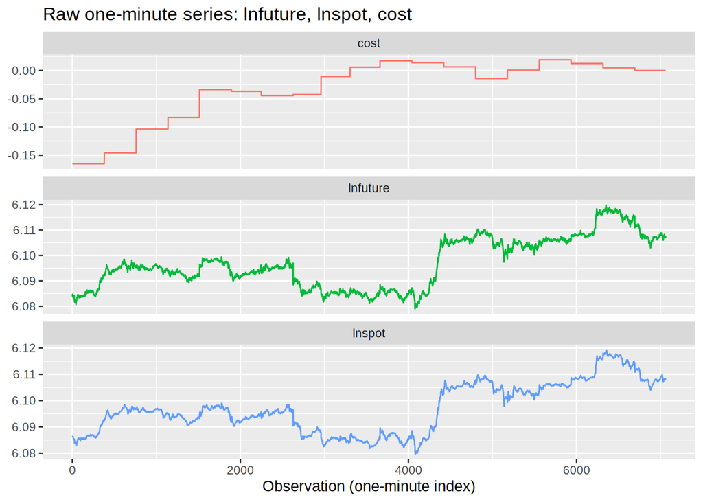

```r
sp_long <- sp %>%
  mutate(index = row_number()) %>%
  pivot_longer(-index, names_to = "series", values_to = "value")

ggplot(sp_long, aes(x = index, y = value, colour = series)) +
  geom_line() +
  facet_wrap(~series, scales = "free_y", ncol = 1) +
  labs(x = "Observation (one‑minute index)", y = NULL,
       title = "Raw one‑minute series: lnfuture, lnspot, cost") +
  theme(legend.position = "none")
```

We can definitely see some trends in this data, so, as stated in the task, we consider the first differences: $y_t = f_t − f_{t-1}$ and $x_t = s_t − s_{t−1}$, where $f_t$ and $s_t$ are lnfuture and lnspot respectively.

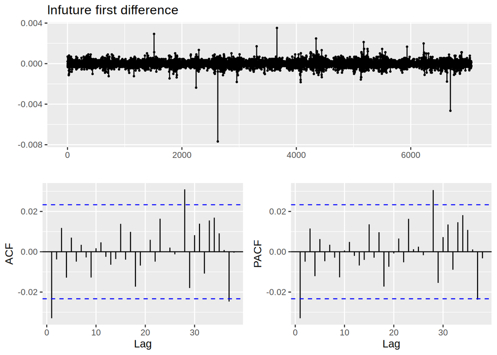

```r
library(forecast)

sp_diff <- sp %>%
  mutate(
    y = lnfuture - lag(lnfuture),
    x = lnspot   - lag(lnspot)
  ) %>%
  drop_na()

ggtsdisplay(sp_diff$y, main = "lnfuture first difference")
```

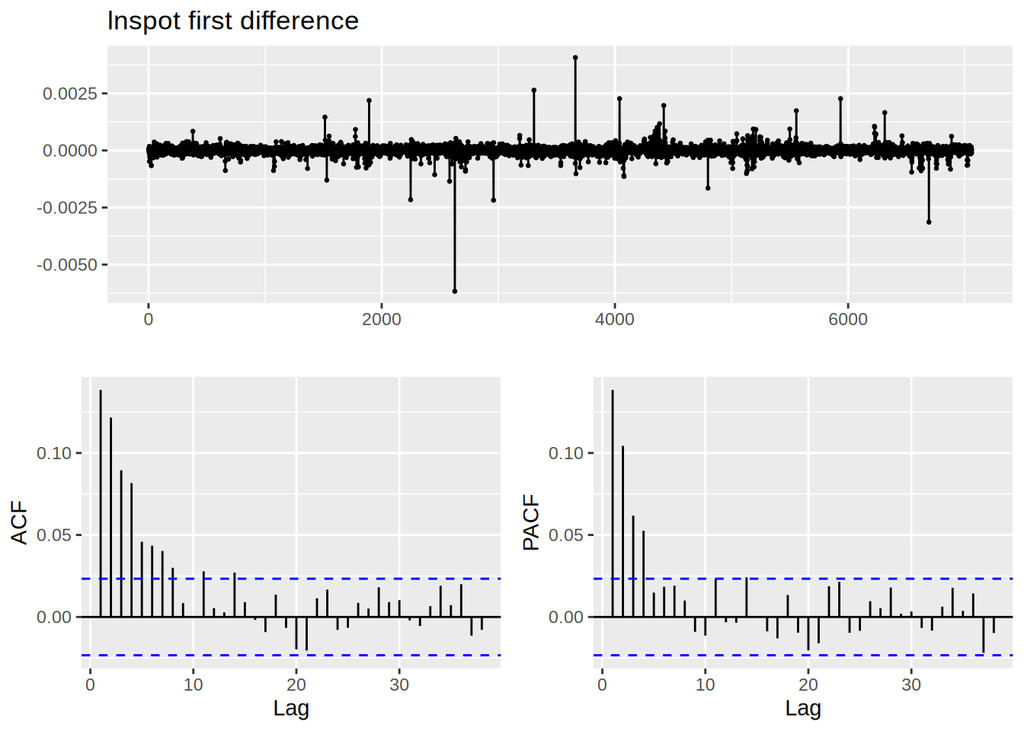

```r
ggtsdisplay(sp_diff$x,   main = "lnspot first difference")
```

Now we can build a regression model between these variables.

```r
ols_fit <- lm(y ~ x, data = sp_diff)
summary(ols_fit)
```

```
##
## Call:
## lm(formula = y ~ x, data = sp_diff)
##
## Residuals:
##        Min         1Q     Median         3Q        Max
## -0.0038484 -0.0001568 -0.0000014  0.0001612  0.0026256
##
## Coefficients:
##              Estimate Std. Error t value Pr(>|t|)
## (Intercept) 1.354e-06  3.509e-06   0.386      0.7
## x           6.212e-01  1.754e-02  35.420   <2e-16 ***
## ---
## Signif. codes:  0 '***' 0.001 '**' 0.01 '*' 0.05 '.' 0.1 ' ' 1
##
## Residual standard error: 0.0002948 on 7058 degrees of freedom
## Multiple R-squared:  0.1509, Adjusted R-squared:  0.1508
## F-statistic:  1255 on 1 and 7058 DF,  p-value: < 2.2e-16
```

We can see that our $\beta_0 = 1.354e-06$ and $\beta_1= 6.212e-01$.

Now we can move on to the residuals.

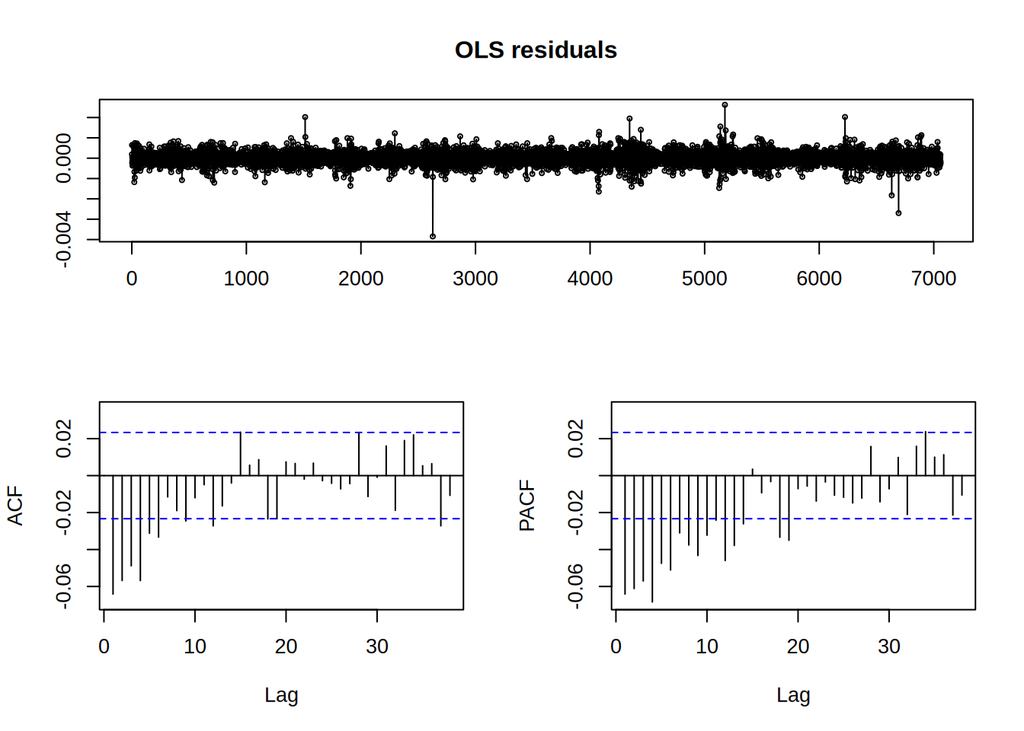

```r
tsdisplay(residuals(ols_fit), main = "OLS residuals")
```

```r
Box.test(residuals(ols_fit), lag = 20, type = "Ljung-Box")
```

```
##
##  Box-Ljung test
##
## data:  residuals(ols_fit)
## X-squared = 135.02, df = 20, p-value < 2.2e-16
```

These residuals definitely aren’t white noise - the ACF and PACF values for the first several lags, as well as the low p-value for the Ljung-Box statistic are strong indicators of that. So let’s fit an ARMA model to the residuals.

```r
set.seed(1)
arma_fit <- auto.arima(residuals(ols_fit), stationary = TRUE,
                       seasonal = FALSE, stepwise = FALSE, approximation = FALSE)
arma_fit
```

```
## Series: residuals(ols_fit)
## ARIMA(1,0,1) with zero mean
##
## Coefficients:
##          ar1      ma1
##       0.8179  -0.9196
## s.e.  0.0152   0.0102
##
## sigma^2 = 8.429e-08:  log likelihood = 47483.26
## AIC=-94960.51   AICc=-94960.51   BIC=-94939.93
```

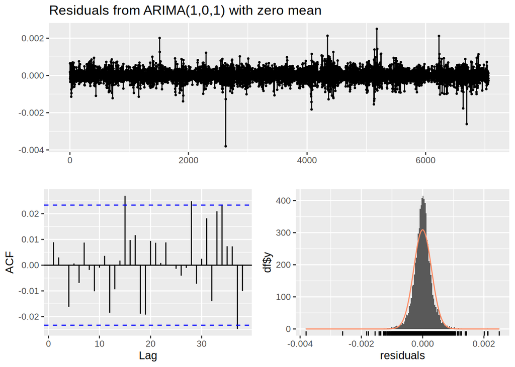

```
##
##  Ljung-Box test
##
## data:  Residuals from ARIMA(1,0,1) with zero mean
## Q* = 4.1181, df = 8, p-value = 0.8463
##
## Model df: 2.   Total lags used: 10
```

```r
checkresiduals(arma_fit)
```

Way better - now these residuals actually look like white noise with some proper normal distribution. Now let’s restrict model selection to AR(p) and check for satisfactory model to improve over white noise.

```r
arma_fit <- auto.arima(residuals(ols_fit), stationary = TRUE,
                       seasonal = FALSE, stepwise = FALSE, approximation = FALSE, max.q = 0, max.d = 0)
arma_fit
```

```
## Series: residuals(ols_fit)
## ARIMA(5,0,0) with zero mean
##
## Coefficients:
##           ar1      ar2      ar3      ar4      ar5
##       -0.0787  -0.0724  -0.0652  -0.0720  -0.0475
## s.e.   0.0119   0.0119   0.0119   0.0119   0.0119
##
## sigma^2 = 8.541e-08:  log likelihood = 47438.54
## AIC=-94865.07   AICc=-94865.06   BIC=-94823.9
```

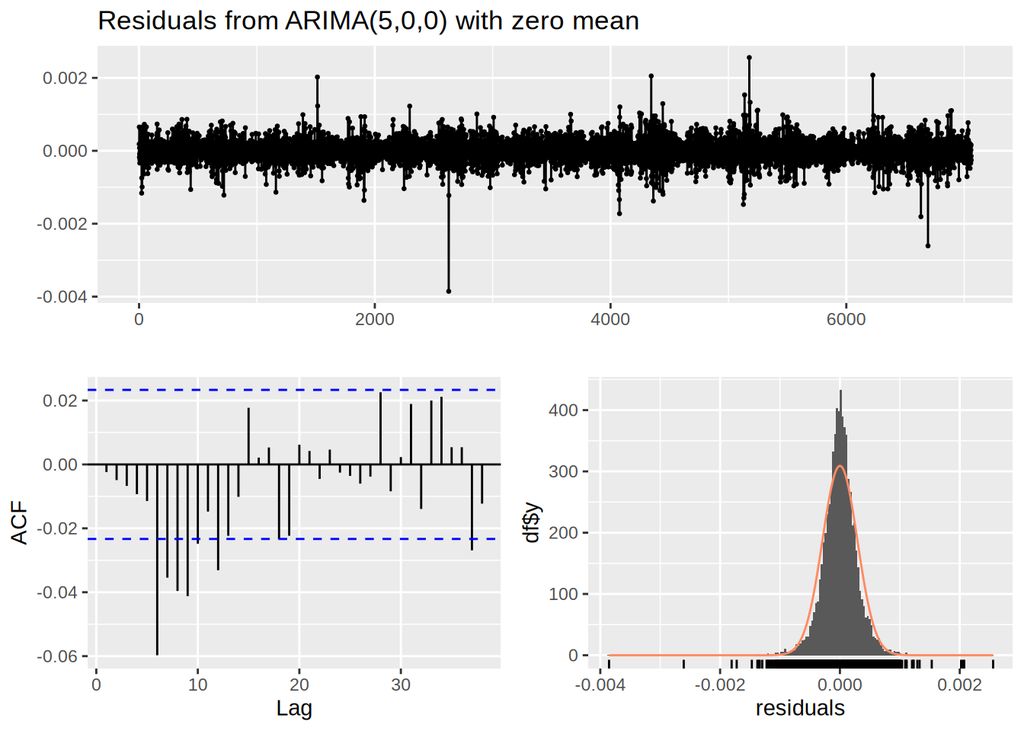

```
##
##  Ljung-Box test
##
## data:  Residuals from ARIMA(5,0,0) with zero mean
## Q* = 63.599, df = 5, p-value = 2.188e-12
##
## Model df: 5.   Total lags used: 10
```

```r
checkresiduals(arma_fit)
```

Well, is it an improvement over white noise? Yes. Is it satisfactory with that ACF and Ljung-Box statistics? Not necessarily - ARMA(1,1) did a way better job.

Lastly, let’s get the final coefficients and model accuracy.

```r
coeftest(ols_fit)
```

```
##
## t test of coefficients:
##
##               Estimate Std. Error t value Pr(>|t|)
## (Intercept) 1.3538e-06 3.5093e-06  0.3858   0.6997
## x           6.2122e-01 1.7539e-02 35.4195   <2e-16 ***
## ---
## Signif. codes:  0 '***' 0.001 '**' 0.01 '*' 0.05 '.' 0.1 ' ' 1
```

```r
forecast::accuracy(ols_fit)
```

```
##                       ME         RMSE          MAE MPE MAPE      MASE
## Training set 4.89848e-20 0.0002947897 0.0002117443 NaN  Inf 0.9873638
```

# Task 2

As always, we start from loading the data and having a look at it.

```r
www2 <- "https://www.mimuw.edu.pl/~noble/courses/TimeSeries/data/q-gdpdef.txt"
gdp=read.table(www2,header = T)
head(gdp)
```

```
##   year mom day gdpdef
## 1 1947   1   1 15.105
## 2 1947   4   1 15.329
## 3 1947   7   1 15.597
## 4 1947  10   1 15.989
## 5 1948   1   1 16.111
## 6 1948   4   1 16.254
```

```r
gdp_ts <- ts(gdp$gdpdef, start = c(1947, 1), frequency = 4)
```

Let’s plot it and see how it behaves.

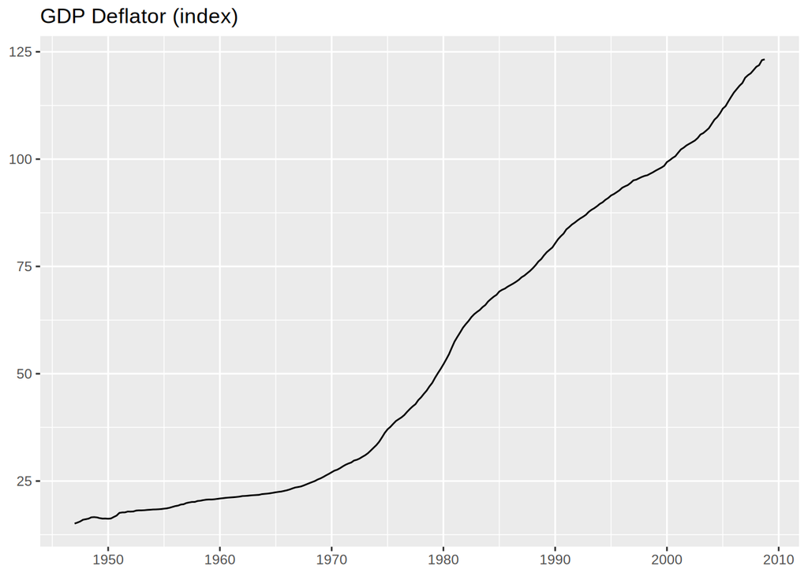

```r
autoplot(gdp_ts) +
  labs(title = "GDP Deflator (index)", x = NULL, y = NULL)
```

```r
kpss.test(gdp_ts)
```

```
##
##  KPSS Test for Level Stationarity
##
## data:  gdp_ts
## KPSS Level = 4.119, Truncation lag parameter = 5, p-value = 0.01
```

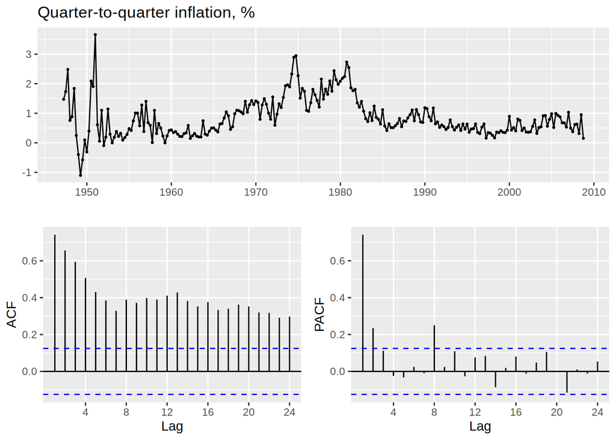

```r
infl_q <- diff(log(gdp_ts)) * 100
trend   <- seq_along(infl_q)

ggtsdisplay(infl_q, main = "Quarter-to-quarter inflation, %")
```

```r
kpss <- kpss.test(infl_q, null = "Level")
adf <- adf.test(infl_q)
kpss$p.value; adf$p.value
```

```
## [1] 0.04501114
```

```
## [1] 0.06453896
```

We can see that taking both of the tests into consideration, we are in some sort of “grey zone” when it comes to stationarity. It could mean some uncaptured structure, as well as conditional heteroskedasticity. We will try both ways: fitting an ARMA model as well as fitting ARMA-GARCH model and observe the results. As it is said that the data is seasonally adjusted, we will exclude any seasonality in our thought process.

We’ll start from simple auto ARIMA with d=0, as we already took the first difference.

```r
fit_auto <- auto.arima(infl_q,
                       d = 0,
                       seasonal      = FALSE,
                       stepwise      = FALSE,
                       approximation = FALSE,
                       ic            = "aicc")
fit_auto
```

```
## Series: infl_q
## ARIMA(1,0,1) with non-zero mean
##
## Coefficients:
##          ar1      ma1    mean
##       0.8903  -0.3494  0.8576
## s.e.  0.0365   0.0747  0.1538
##
## sigma^2 = 0.1786:  log likelihood = -136.68
## AIC=281.36   AICc=281.53   BIC=295.4
```

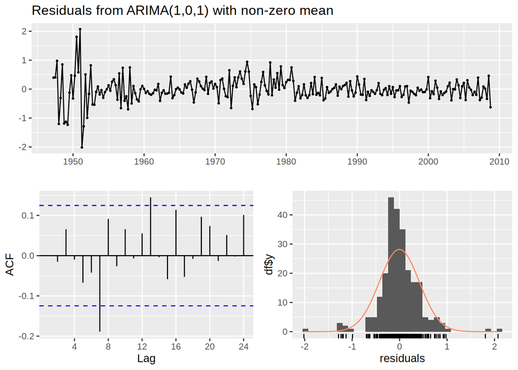

```
##
##  Ljung-Box test
##
## data:  Residuals from ARIMA(1,0,1) with non-zero mean
## Q* = 14.058, df = 6, p-value = 0.029
##
## Model df: 2.   Total lags used: 8
```

```r
checkresiduals(fit_auto)
```

The Ljung-Box test results on the residuals are clearly unsatisfactory and we can see some spikes in the residuals ACF. Let’s try to capture that by manually fitting an ARMA (8,0) model instead:

```r
fit_ar8 <- Arima(infl_q,
                 order = c(8, 0, 0),
                 include.constant = TRUE)
fit_ar8
```

```
## Series: infl_q
## ARIMA(8,0,0) with non-zero mean
##
## Coefficients:
##          ar1     ar2     ar3      ar4      ar5     ar6      ar7     ar8    mean
##       0.5479  0.1624  0.1632  -0.0215  -0.0786  0.0021  -0.1739  0.2610  0.8525
## s.e.  0.0616  0.0705  0.0727   0.0736   0.0740  0.0758   0.0746  0.0658  0.1783
##
## sigma^2 = 0.1698:  log likelihood = -127.67
## AIC=275.34   AICc=276.27   BIC=310.43
```

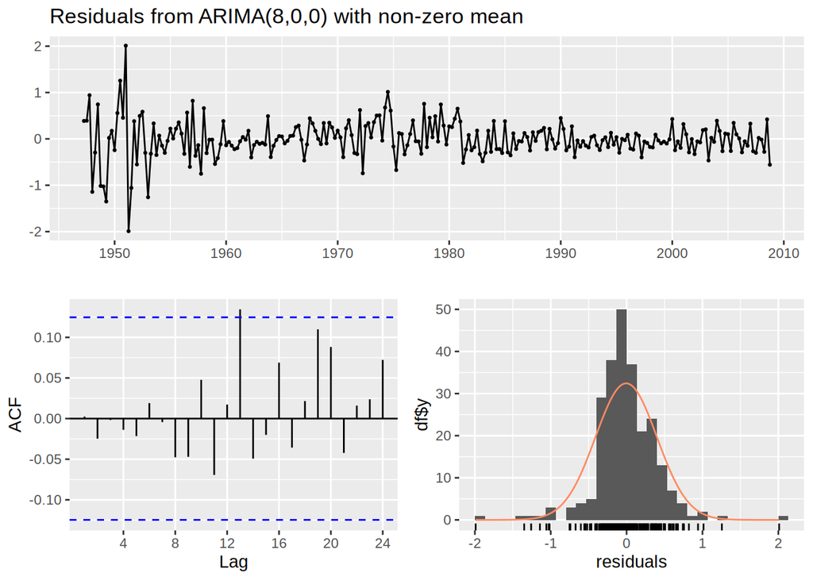

```
##
##  Ljung-Box test
##
## data:  Residuals from ARIMA(8,0,0) with non-zero mean
## Q* = 3.4207, df = 3, p-value = 0.3312
##
## Model df: 8.   Total lags used: 11
```

```r
checkresiduals(fit_ar8)
```

```r
coeftest(fit_ar8)
```

```
##
## z test of coefficients:
##
##             Estimate Std. Error z value  Pr(>|z|)
## ar1        0.5479066  0.0616460  8.8880 < 2.2e-16 ***
## ar2        0.1623737  0.0705093  2.3029   0.02129 *
## ar3        0.1631947  0.0726725  2.2456   0.02473 *
## ar4       -0.0215097  0.0736490 -0.2921   0.77024
## ar5       -0.0785692  0.0740003 -1.0617   0.28835
## ar6        0.0020687  0.0758177  0.0273   0.97823
## ar7       -0.1738668  0.0745843 -2.3311   0.01975 *
## ar8        0.2609888  0.0658168  3.9654 7.328e-05 ***
## intercept  0.8525128  0.1782856  4.7817 1.738e-06 ***
## ---
## Signif. codes:  0 '***' 0.001 '**' 0.01 '*' 0.05 '.' 0.1 ' ' 1
```

Way better - we can see an improvement in both AICc and Ljung-Box statistic, although the model is quite complicated. Now let’s try an ARMA-GARCH model (when it comes to the parameters, I performed a manual search based on sthe statistic significance, so I won’t include all of that here).

```r
fit <- garchFit(~ arma(4,4) + garch(1,1),
                data       = infl_q,
                cond.dist  = "norm",
                include.mean = TRUE,
                xreg       = trend,
                trace      = FALSE)

summary(fit)
```

```
##
## Title:
##  GARCH Modelling
##
## Call:
##  garchFit(formula = ~arma(4, 4) + garch(1, 1), data = infl_q,
##     cond.dist = "norm", include.mean = TRUE, trace = FALSE, xreg = trend)
##
## Mean and Variance Equation:
##  data ~ arma(4, 4) + garch(1, 1)
## <environment: 0x58517cf1a128>
##  [data = infl_q]
##
## Conditional Distribution:
##  norm
##
## Coefficient(s):
##         mu         ar1         ar2         ar3         ar4         ma1
##  0.1944744   0.0058431   0.0145093  -0.0319492   0.7236921   0.3803616
##        ma2         ma3         ma4       omega      alpha1       beta1
##  0.4345049   0.4431932  -0.2481702   0.0095225   0.4817198   0.5180500
##
## Std. Errors:
##  based on Hessian
##
## Error Analysis:
##         Estimate  Std. Error  t value Pr(>|t|)
## mu      0.194474    0.060644    3.207 0.001342 **
## ar1     0.005843    0.065345    0.089 0.928748
## ar2     0.014509    0.052804    0.275 0.783486
## ar3    -0.031949    0.051166   -0.624 0.532347
## ar4     0.723692    0.058596   12.350  < 2e-16 ***
## ma1     0.380362    0.098263    3.871 0.000108 ***
## ma2     0.434505    0.081977    5.300 1.16e-07 ***
## ma3     0.443193    0.078552    5.642 1.68e-08 ***
## ma4    -0.248170    0.072005   -3.447 0.000568 ***
## omega   0.009523    0.004263    2.234 0.025506 *
## alpha1  0.481720    0.139120    3.463 0.000535 ***
## beta1   0.518050    0.107512    4.819 1.45e-06 ***
## ---
```

[output cut: 9 more lines]

```
## Standardised Residuals Tests:
##                                  Statistic    p-Value
##  Jarque-Bera Test   R    Chi^2   6.2907177 0.04305147
##  Shapiro-Wilk Test  R    W       0.9835379 0.00589013
##  Ljung-Box Test     R    Q(10)   5.8755681 0.82560683
##  Ljung-Box Test     R    Q(15)   9.1599412 0.86900713
##  Ljung-Box Test     R    Q(20)  14.1576456 0.82241379
##  Ljung-Box Test     R^2  Q(10)  13.3614595 0.20415837
##  Ljung-Box Test     R^2  Q(15)  17.0568298 0.31547848
##  Ljung-Box Test     R^2  Q(20)  19.0259916 0.52013712
##  LM Arch Test       R    TR^2   18.1147359 0.11225090
##
## Information Criterion Statistics:
##       AIC       BIC       SIC      HQIC
## 0.5249618 0.6954584 0.5205263 0.5936051
```

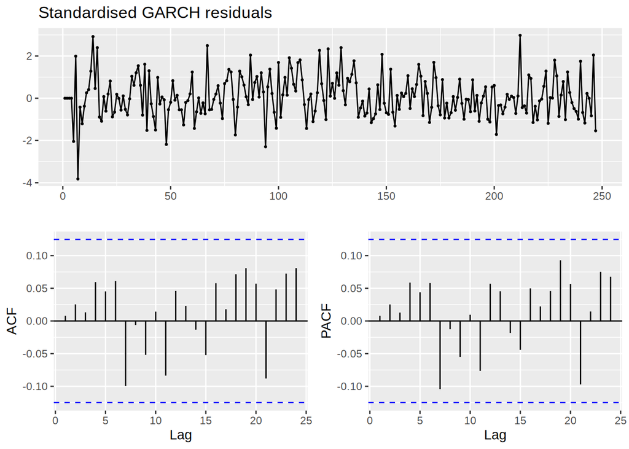

```r
std.res <- residuals(fit, standardize = TRUE)

ggtsdisplay(std.res, main = "Standardised GARCH residuals")
```

```r
print(Box.test(std.res,  lag = 16, type = "Ljung-Box"))
```

```
##
##  Box-Ljung test
##
## data:  std.res
## X-squared = 10.05, df = 16, p-value = 0.864
```

```r
print(Box.test(std.res^2, lag = 16, type = "Ljung-Box"))
```

```
##
##  Box-Ljung test
##
## data:  std.res^2
## X-squared = 17.838, df = 16, p-value = 0.3334
```

```r
garch_obj <- fit
h         <- 4
coef_vec <- coef(garch_obj)

phi      <- coef_vec[grep("^ar", names(coef_vec))]
theta    <- coef_vec[grep("^ma", names(coef_vec))]
mu       <- coef_vec["mu"]

omega    <- coef_vec["omega"]
alpha1   <- coef_vec[grep("^alpha1", names(coef_vec))]
beta1    <- coef_vec[grep("^beta1",  names(coef_vec))]

p <- length(phi)
q <- length(theta)

y  <- garch_obj@data
e  <- residuals(garch_obj)
s2 <- garch_obj@sigma.t^2

y_lag <- rev(tail(y, p))
e_lag <- rev(tail(e, q))
sig2  <- tail(s2, 1)

y_fc      <- numeric(h)
sigma2_fc <- numeric(h)

for (i in 1:h) {

  y_hat <- mu +
           sum(phi   * y_lag[1:p]) +
           sum(theta * e_lag[1:q])
  y_fc[i] <- y_hat

  y_lag <- c(y_hat, head(y_lag, p - 1))
  e_lag <- c(0, head(e_lag, q - 1))

  if (i == 1) {
    sigma2_fc[i] <- omega + alpha1 * e_lag[2]^2 + beta1 * sig2
  } else {
    sigma2_fc[i] <- omega + (alpha1 + beta1) * sigma2_fc[i - 1]
  }
}

se <- sqrt(sigma2_fc)
out <- data.frame(
  Quarter = paste0("2009 Q", 1:h),
  Point   = round(y_fc,     2),
  Lower95 = round(y_fc - 1.96 * se, 2),
  Upper95 = round(y_fc + 1.96 * se, 2)
)

print(out)
```

```
##   Quarter Point Lower95 Upper95
## 1 2009 Q1  0.56   -0.37    1.49
## 2 2009 Q2  0.40   -0.55    1.35
## 3 2009 Q3  0.53   -0.44    1.50
## 4 2009 Q4  0.43   -0.55    1.42
```

# Task 3

As always, we’ll start from loading and plotting the dataset:

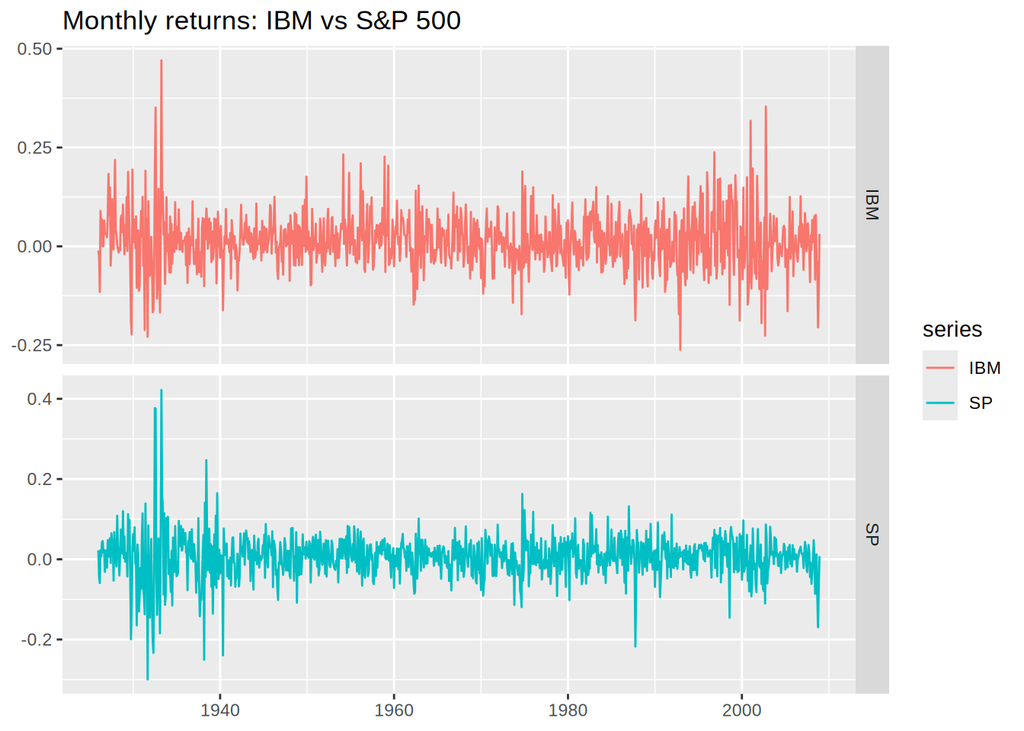

```r
www3 <- "https://www.mimuw.edu.pl/~noble/courses/TimeSeries/data/m-ibmsp2608.txt"
ibmsp=read.table(www3,header = T)
ibm_ts <- ts(ibmsp$ibm, start = c(1926, 1), frequency = 12)
sp_ts  <- ts(ibmsp$sp,  start = c(1926, 1), frequency = 12)

autoplot(cbind(IBM = ibm_ts, SP = sp_ts)) +
  facet_grid(vars(series), scales = "free_y") +
  labs(title = "Monthly returns: IBM vs S&P 500", x = NULL, y = NULL)
```

We can definitely see some similarity, especially the volatile chunk in the beginning and a decrease in the end.

Now we’ll do the scatterplots: IBM versus S&P 500 at lags of 0 and ±1, as well as S&P 500 versus S&P 500 at lag 1.

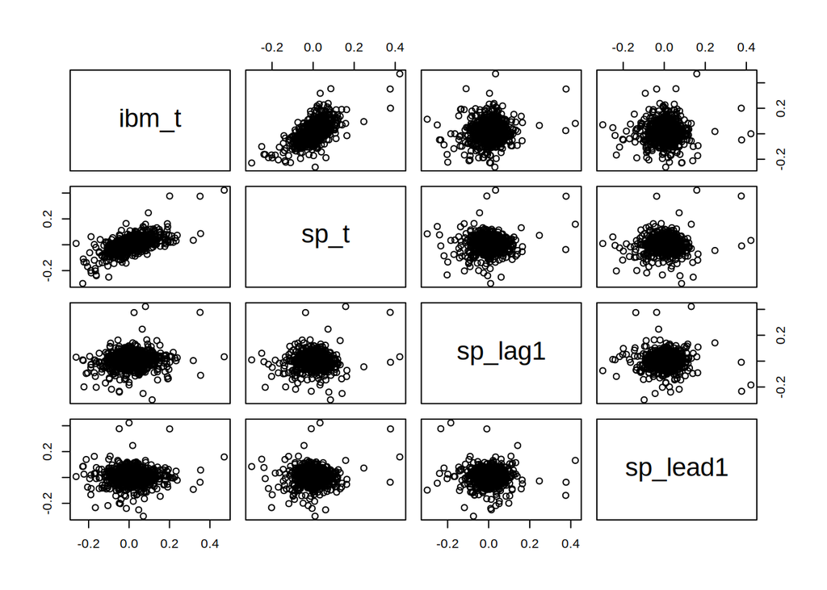

```r
lag <- function(x, k) dplyr::lag(x, k)

df <- ibmsp %>%
  transmute(
    ibm_t    = ibm,
    sp_t     = sp,
    sp_lag1  = lag(sp,  1),   # SP_{t-1}
    sp_lead1 = lead(sp, 1)    # SP_{t+1}
  )

pairs(df, labels = colnames(df))
```

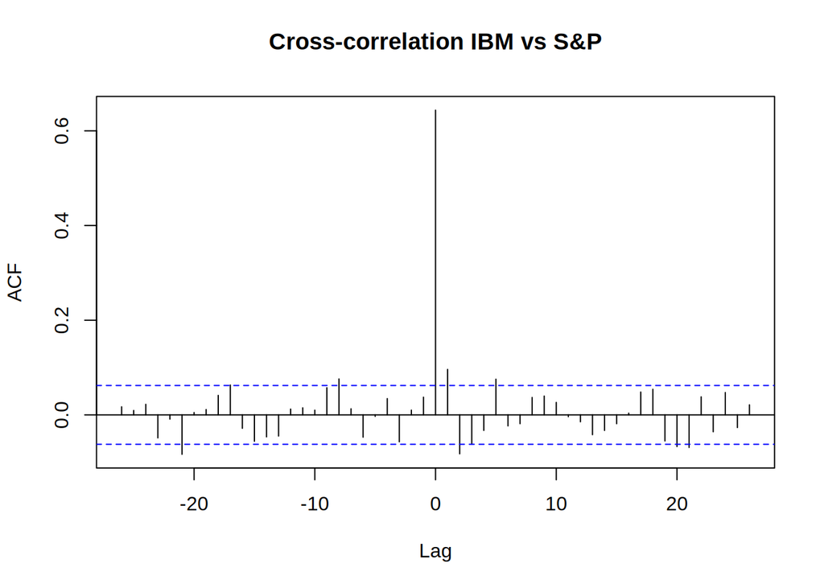

```r
ccf(df$ibm_t, df$sp_t, main = "Cross-correlation IBM vs S&P")
```

Now let’s try fitting a VAR model to the data.

```r
ibmsp_ts <- ts(ibmsp[,c("ibm","sp")], start = c(1926,1), frequency = 12)

lag_select <- VARselect(ibmsp_ts, lag.max = 12, type = "const")
lag_select$criteria
```

```
##                    1             2             3             4             5
## AIC(n) -1.158784e+01 -1.159294e+01 -1.159727e+01 -1.159654e+01 -1.159841e+01
## HQ(n)  -1.157649e+01 -1.157403e+01 -1.157080e+01 -1.156250e+01 -1.155682e+01
## SC(n)  -1.155801e+01 -1.154323e+01 -1.152768e+01 -1.150706e+01 -1.148905e+01
## FPE(n)  9.278258e-06  9.231044e-06  9.191133e-06  9.197871e-06  9.180646e-06
##                    6             7             8             9            10
## AIC(n) -1.159339e+01 -1.158743e+01 -1.158691e+01 -1.158530e+01 -1.157889e+01
## HQ(n)  -1.154422e+01 -1.153070e+01 -1.152262e+01 -1.151344e+01 -1.149948e+01
## SC(n)  -1.146414e+01 -1.143829e+01 -1.141789e+01 -1.139639e+01 -1.137010e+01
## FPE(n)  9.226941e-06  9.282086e-06  9.286915e-06  9.301952e-06  9.361725e-06
##                   11            12
## AIC(n) -1.157220e+01 -1.156530e+01
## HQ(n)  -1.148522e+01 -1.147076e+01
## SC(n)  -1.134353e+01 -1.131674e+01
## FPE(n)  9.424654e-06  9.489956e-06
```

```r
best_p <- lag_select$selection["AIC(n)"]

var_best <- VAR(ibmsp_ts, p = best_p, type = "const")
summary(var_best)
```

```
##
## VAR Estimation Results:
## =========================
## Endogenous variables: ibm, sp
## Deterministic variables: const
## Sample size: 991
## Log Likelihood: 2961.573
## Roots of the characteristic polynomial:
## 0.6354 0.6354 0.6329 0.6329 0.5682 0.5536 0.5536 0.5025 0.5025 0.3598
## Call:
## VAR(y = ibmsp_ts, p = best_p, type = "const")
##
##
## Estimation results for equation ibm:
## ====================================
## ibm = ibm.l1 + sp.l1 + ibm.l2 + sp.l2 + ibm.l3 + sp.l3 + ibm.l4 + sp.l4 + ibm.l5 + sp.l5 + const
##
##         Estimate Std. Error t value Pr(>|t|)
## ibm.l1 -0.034395   0.041426  -0.830  0.40658
## sp.l1   0.157090   0.053401   2.942  0.00334 **
## ibm.l2  0.084424   0.041360   2.041  0.04150 *
## sp.l2  -0.166425   0.053519  -3.110  0.00193 **
## ibm.l3  0.045670   0.041434   1.102  0.27063
## sp.l3  -0.108678   0.053663  -2.025  0.04312 *
## ibm.l4 -0.025497   0.041208  -0.619  0.53623
## sp.l4  -0.008121   0.053909  -0.151  0.88028
## ibm.l5 -0.054317   0.041214  -1.318  0.18783
## sp.l5   0.133708   0.053877   2.482  0.01324 *
## const   0.013284   0.002445   5.434 6.96e-08 ***
## ---
## Signif. codes:  0 '***' 0.001 '**' 0.01 '*' 0.05 '.' 0.1 ' ' 1
##
##
## Residual standard error: 0.07067 on 980 degrees of freedom
## Multiple R-Squared: 0.03235, Adjusted R-squared: 0.02247
## F-statistic: 3.276 on 10 and 980 DF,  p-value: 0.0003492
##
##
## Estimation results for equation sp:
## ===================================
```

[output cut: 18 more lines]

```
## Residual standard error: 0.05476 on 980 degrees of freedom
## Multiple R-Squared: 0.03312, Adjusted R-squared: 0.02325
## F-statistic: 3.357 on 10 and 980 DF,  p-value: 0.0002579
##
##
##
## Covariance matrix of residuals:
##          ibm       sp
## ibm 0.004994 0.002466
## sp  0.002466 0.002998
##
## Correlation matrix of residuals:
##        ibm     sp
## ibm 1.0000 0.6373
## sp  0.6373 1.0000
```

```r
serial.test(var_best, lags.pt = 16, type = "PT.asymptotic")
```

```
##
##  Portmanteau Test (asymptotic)
##
## data:  Residuals of VAR object var_best
## Chi-squared = 46.607, df = 44, p-value = 0.3657
```

The best model appeared to be VAR(5).

```r
library(car)

# already fitted:
var5 <- VAR(ibmsp_ts, p = 5, type = "const")

## Wald test in IBM equation  (H0: ibm.l4 = sp.l4 = 0)
lh_ibm <- linearHypothesis(
  var5$varresult$ibm,
  c("ibm.l4 = 0", "sp.l4 = 0"),
  test = "Chisq")
print(lh_ibm)
```

```
##
## Linear hypothesis test:
## ibm.l4 = 0
## sp.l4 = 0
##
## Model 1: restricted model
## Model 2: y ~ -1 + (ibm.l1 + sp.l1 + ibm.l2 + sp.l2 + ibm.l3 + sp.l3 +
##     ibm.l4 + sp.l4 + ibm.l5 + sp.l5 + const)
##
##   Res.Df    RSS Df Sum of Sq  Chisq Pr(>Chisq)
## 1    982 4.8989
## 2    980 4.8945  2  0.004394 0.8798     0.6441
```

```r
## Wald test in S&P-500 equation  (same restriction)
lh_sp <- linearHypothesis(
  var5$varresult$sp,
  c("ibm.l4 = 0", "sp.l4 = 0"),
  test = "Chisq")
print(lh_sp)
```

```
##
## Linear hypothesis test:
## ibm.l4 = 0
## sp.l4 = 0
##
## Model 1: restricted model
## Model 2: y ~ -1 + (ibm.l1 + sp.l1 + ibm.l2 + sp.l2 + ibm.l3 + sp.l3 +
##     ibm.l4 + sp.l4 + ibm.l5 + sp.l5 + const)
##
##   Res.Df    RSS Df Sum of Sq Chisq Pr(>Chisq)
## 1    982 2.9427
## 2    980 2.9382  2 0.0045063 1.503     0.4717
```

As we defined $H_0$: lag-4 coefficients are zero, we failed to reject it, therefore it is reasonable to delete them from the model.

To check whether the current return of IBM stock is influence by past behaviour of the market index, we’ll check the significance of first several lags of sp in the ibm equation. We can notice that sp.l1, sp.l2, and sp.l3 are significant, therefore we can conclude that it is a true statement. To check whether current return of IBM stock influence future behaviour of the market index, we do the same in reverse, so check the significance of first several lags of ibm in the sp equation. We can notice that only ibm.l5 is at least somehow significant, therefore the statement is not true.

Lastly, we’ll construct a VAR(p) models for the bivariate series.

```r
out <- map_dfr(1:16, function(p){
  m   <- VAR(ibmsp_ts, p = p, type = "const")
  lb  <- serial.test(m, lags.pt = 16,
                     type = "PT.asymptotic")$serial$p.value
  tibble(p = p,
         AIC = AIC(m),
         LBp = lb)
})
print(out)
```

```
## # A tibble: 16 × 3
##        p    AIC    LBp
##    <int>  <dbl>  <dbl>
##  1     1 -5895. 0.0100
##  2     2 -5893. 0.0884
##  3     3 -5893. 0.154
##  4     4 -5885. 0.235
##  5     5 -5879. 0.366
##  6     6 -5867. 0.340
##  7     7 -5855. 0.217
##  8     8 -5846. 0.355
##  9     9 -5837. 0.500
## 10    10 -5824. 0.377
## 11    11 -5810. 0.197
## 12    12 -5795. 0.0799
## 13    13 -5786. 0.0784
## 14    14 -5779. 0.0983
## 15    15 -5776. 0.0233
## 16    16 -5770. 0
```

So we choose the lowest p that eliminates the autocorrelation of the residuals - p=2.